# IE_360_Assignment1_Erce_Sezgun

me

2024-02-22

# -IE 360 Assignment 1 *-*

### by *Erce Sezgün 2020402174*

- In this assignment there are three data that have taken from the internet and one by one modeled. Employment rate, accommodation costs, and manufacturing industry capacity utilization rate. Before going to the questions that asked for the models and data that used for them, it is needed to check if they are correlated to each other and if they are higher than 0.5 we have to reject and find other topic to discuss.

```r
require(data.table)
require(lubridate)
require(forecast)
require(skimr)
require(repr)
require(readxl)
```

```r
library(ggplot2)
require(GGally)
require(ggcorrplot)
require(forecast)
```

- In the block below it is tested if topics are correlated to each other or not. Apparently all the topics have less correlation than the value 0,5. Process can continue.

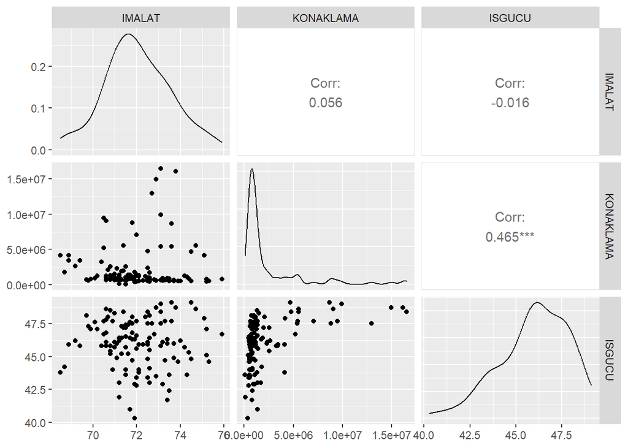

```r
Topics <- read_excel("C://Users/erces/Documents/Topics.xlsx")
topics <- Topics
topics=data.table(topics)
ggpairs(topics)
```

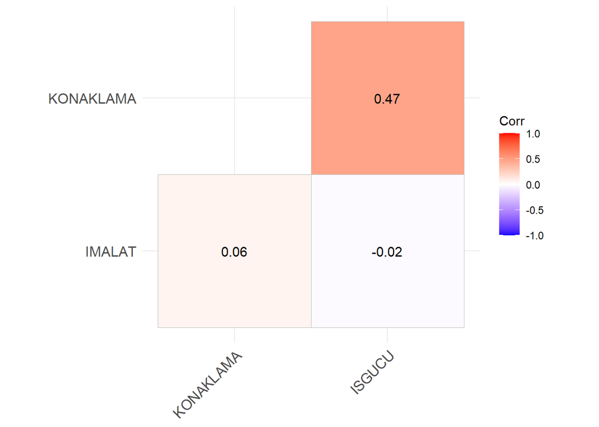

```r
correl_info=cor(topics)

ggcorrplot(correl_info,
           hc.order = TRUE,
           type = "lower",
           lab = TRUE)
```

# 1)Employment Rate

- Firstly, the employment rate is analyzed whether or not they can be analyzed by the house renting prices and up to 1 year maturity deposits opened in Turkish Lira. Idea behind it is that the rise in the rental prices can cause unemployed people to be employed and urge them to work. In the other hand, deposit levels can also effect people as they might choose unemployment if they had enough money in their bank accounts.

```r
options(repr.plot.width=12.7, repr.plot.height=8.5)
data_path_2=read_excel("C://Users/erces/Documents/ISGUCU.xlsx")
emp_rate=data.table(data_path_2)
head(emp_rate,25)
```

```
##          Tarih KONUTSAT ISGUCU  VADELI   KIRA
##  1: 2014-01-01    17489   42.8  9.8140 317.12
##  2: 2014-02-01    17121   43.4 10.9675 318.48
##  3: 2014-03-01    17718   45.2 11.3975 319.67
##  4: 2014-04-01    17130   45.7 11.1550 321.13
##  5: 2014-05-01    17852   46.2 10.3620 323.04
##  6: 2014-06-01    19252   47.4  9.4225 325.48
##  7: 2014-07-01    17116   45.8  8.8475 327.65
##  8: 2014-08-01    17349   45.5  8.8920 329.92
##  9: 2014-09-01    20923   46.4  9.0425 332.79
## 10: 2014-10-01    17240   45.1  9.3300 335.33
## 11: 2014-11-01    19566   44.8  9.4925 336.95
## 12: 2014-12-01    26698   44.6  9.3400 338.72
## 13: 2015-01-01    16587   43.4  9.1880 340.63
## 14: 2015-02-01    17690   44.0  9.3600 342.26
## 15: 2015-03-01    21911   45.2  9.5525 343.69
## 16: 2015-04-01    23197   45.7  9.8975 345.63
## 17: 2015-05-01    21576   46.8 10.2620 347.76
## 18: 2015-06-01    21612   47.3  9.9275 349.78
## 19: 2015-07-01    17182   46.4 10.6120 352.50
## 20: 2015-08-01    18873   47.1  9.9150 355.12
## 21: 2015-09-01    15994   46.5 10.4325 358.09
## 22: 2015-10-01    18468   46.2 10.8040 360.65
## 23: 2015-11-01    20082   46.0 10.9200 363.26
## 24: 2015-12-01    26595   44.9 10.9050 364.90
## 25: 2016-01-01    15526   44.6 11.5840 367.72
##          Tarih KONUTSAT ISGUCU  VADELI   KIRA
```

- In the graph of ISGUCU or employment rate there is a clear trend upwards and a seasonality. Note that in COVID times there is a significant decrease in the employment rate.
- Now correlation between dependent and independent variables are examined below. While there is meaningful correlation between employment with rental prices and deposit levels. It seems that total number of house sold is not helping.

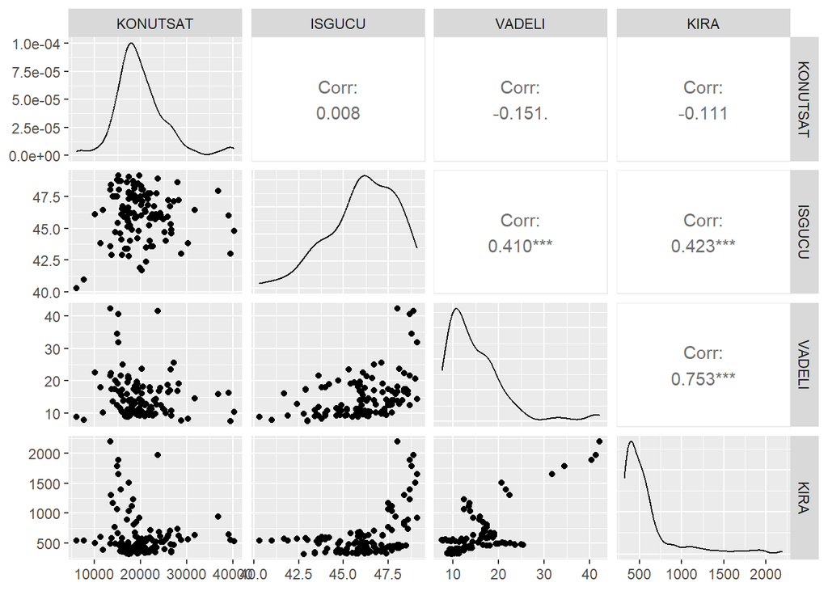

```r
evds_for_correlation <- read_excel("C://Users/erces/Documents/evds_for_correlation.xlsx")

ggpairs(evds_for_correlation)
```

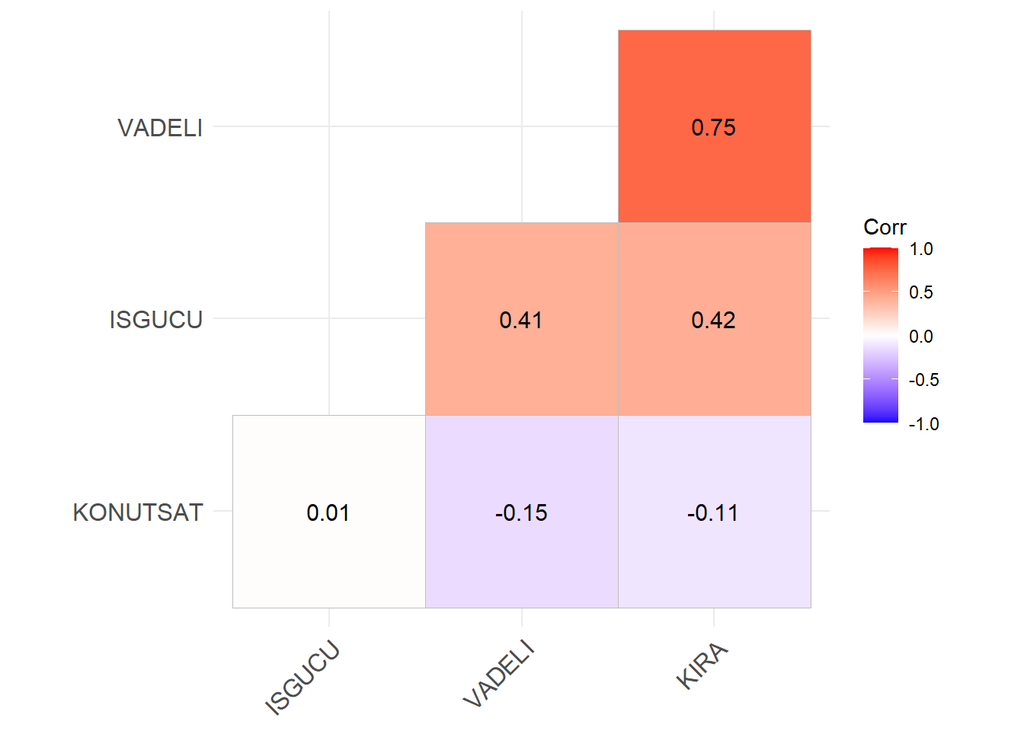

```r
correl_info=cor(evds_for_correlation)

ggcorrplot(correl_info,
           hc.order = TRUE,
           type = "lower",
           lab = TRUE)
```

- Now check the employment rate, it will be called as ISGUCU from now on, graph for general idea for the data. It is clear that data has some trend and seasonality.

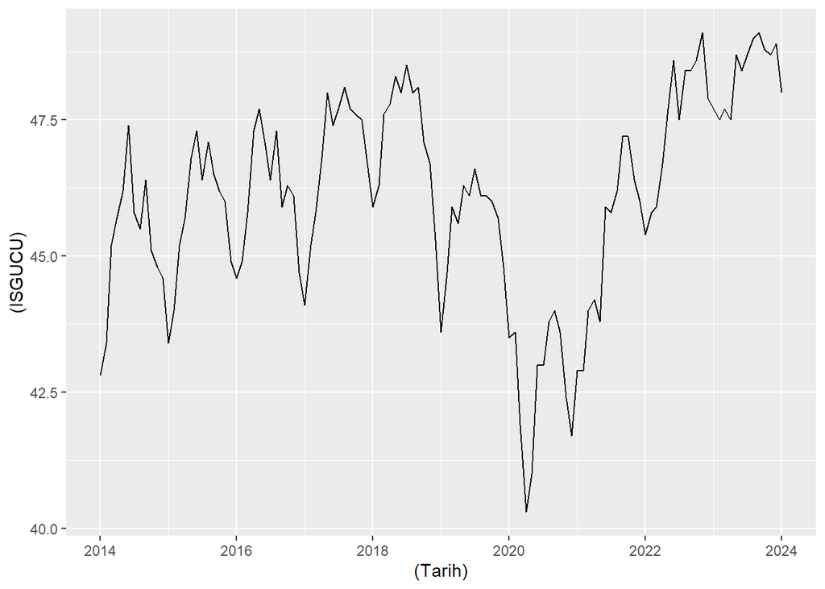

```r
ggplot(emp_rate ,aes(x=(Tarih),y=(ISGUCU))) + geom_line()
```

- Lets start by putting VADELI and KIRA to the model and see the results.

```r
l_fit = lm(ISGUCU~VADELI+KIRA,data=emp_rate)
l_fit
```

```
##
## Call:
## lm(formula = ISGUCU ~ VADELI + KIRA, data = emp_rate)
##
## Coefficients:
## (Intercept)       VADELI         KIRA
##   44.349970     0.061246     0.001394
```

```r
summary(l_fit)
```

```
##
## Call:
## lm(formula = ISGUCU ~ VADELI + KIRA, data = emp_rate)
##
## Residuals:
##     Min      1Q  Median      3Q     Max
## -5.3493 -0.7942  0.2311  1.2539  2.5849
##
## Coefficients:
##              Estimate Std. Error t value Pr(>|t|)
## (Intercept) 4.435e+01  3.914e-01 113.305   <2e-16 ***
## VADELI      6.125e-02  3.655e-02   1.676   0.0964 .
## KIRA        1.394e-03  6.592e-04   2.115   0.0365 *
## ---
## Signif. codes:  0 '***' 0.001 '**' 0.01 '*' 0.05 '.' 0.1 ' ' 1
##
## Residual standard error: 1.703 on 118 degrees of freedom
## Multiple R-squared:  0.1982, Adjusted R-squared:  0.1847
## F-statistic: 14.59 on 2 and 118 DF,  p-value: 2.18e-06
```

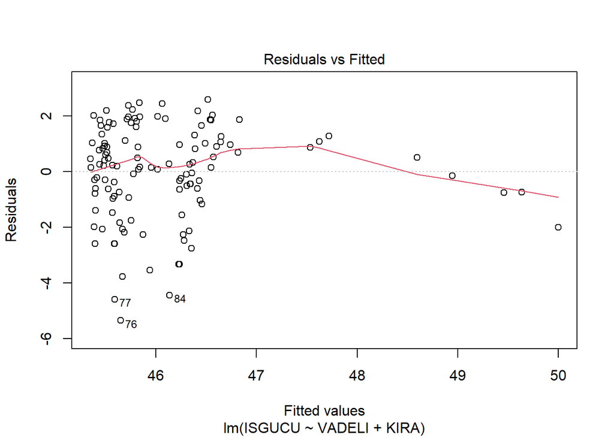

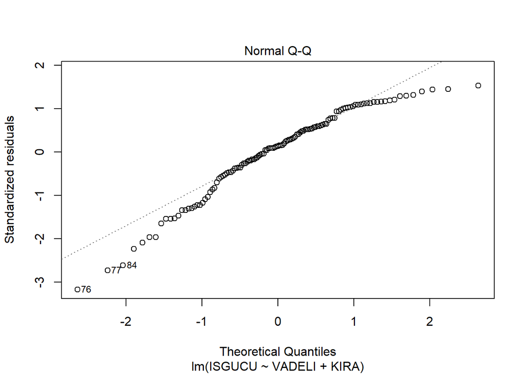

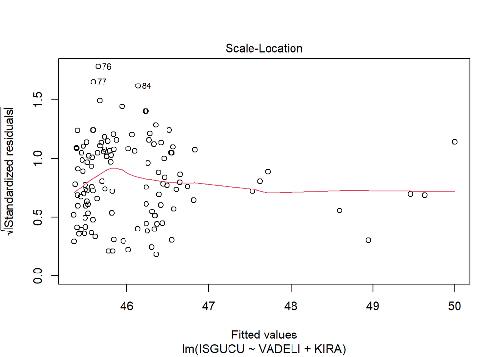

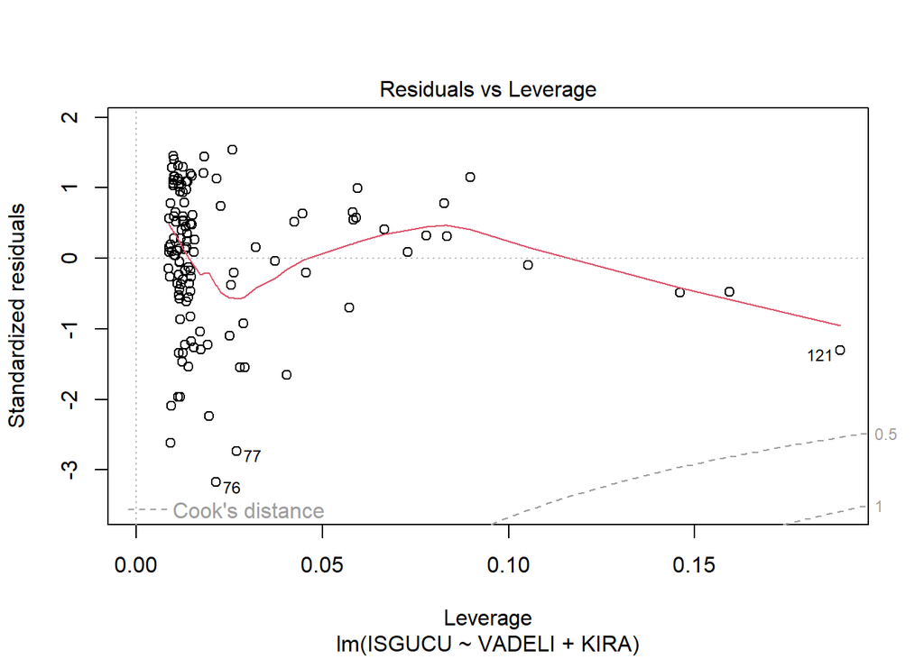

```r
plot(l_fit)
```

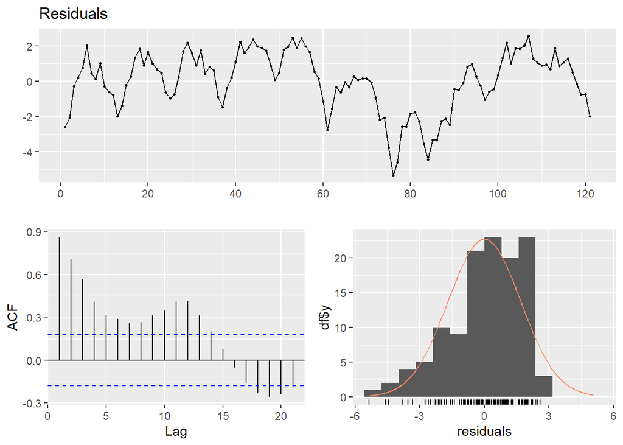

```
##
##  Breusch-Godfrey test for serial correlation of order up to 12
##
## data:  Residuals
## LM test = 97.226, df = 12, p-value = 1.942e-15
```

```r
checkresiduals(l_fit,12)
```

- In the sum above there is great indication for the seasonality.
- New seasonality variables are added to improve the model

```r
emp_rate[,trnd:=1:.N]
emp_rate[,mon:=as.character(month(Tarih,label=T))]
emp_rate[,yıl:=as.character(year(Tarih))]

l_fit = lm(ISGUCU~VADELI+KIRA+yıl+mon,data=emp_rate)
l_fit
```

```
##
## Call:
## lm(formula = ISGUCU ~ VADELI + KIRA + yıl + mon, data = emp_rate)
##
## Coefficients:
## (Intercept)       VADELI         KIRA      yıl2015      yıl2016      yıl2017
##    45.73237     -0.04960      0.00243      0.50499      0.84200      1.56714
##     yıl2018      yıl2019      yıl2020      yıl2021      yıl2022      yıl2023
##     2.16146      0.33439     -3.12772     -0.33084      1.51263      1.14590
##     yıl2024       monAra       monEki       monEyl       monHaz       monKas
##     1.39384     -1.42566     -0.30484      0.02916      0.11140     -0.63762
##      monMar       monMay       monNis       monOca       monŞub       monTem
##    -1.31468     -0.40528     -1.06132     -2.37689     -1.96217     -0.22694
```

```r
summary(l_fit)
```

```
##
## Call:
## lm(formula = ISGUCU ~ VADELI + KIRA + yıl + mon, data = emp_rate)
##
## Residuals:
##      Min       1Q   Median       3Q      Max
## -2.12787 -0.43744 -0.06291  0.43516  2.46179
##
## Coefficients:
##              Estimate Std. Error t value Pr(>|t|)
## (Intercept) 45.732371   0.433280 105.549  < 2e-16 ***
## VADELI      -0.049600   0.028224  -1.757 0.082014 .
## KIRA         0.002430   0.001182   2.056 0.042458 *
## yıl2015      0.504995   0.327431   1.542 0.126258
## yıl2016      0.841997   0.330389   2.548 0.012388 *
## yıl2017      1.567140   0.334389   4.687 9.07e-06 ***
## yıl2018      2.161464   0.364812   5.925 4.76e-08 ***
## yıl2019      0.334394   0.360955   0.926 0.356530
## yıl2020     -3.127718   0.418233  -7.478 3.38e-11 ***
## yıl2021     -0.330844   0.396380  -0.835 0.405958
## yıl2022      1.512635   0.522991   2.892 0.004722 **
## yıl2023      1.145904   1.099284   1.042 0.299813
## yıl2024      1.393836   1.920200   0.726 0.469660
## monAra      -1.425664   0.363067  -3.927 0.000161 ***
## monEki      -0.304842   0.359828  -0.847 0.398975
## monEyl       0.029160   0.359748   0.081 0.935563
## monHaz       0.111397   0.364281   0.306 0.760413
## monKas      -0.637622   0.361071  -1.766 0.080556 .
## monMar      -1.314678   0.364089  -3.611 0.000485 ***
## monMay      -0.405284   0.360907  -1.123 0.264226
## monNis      -1.061320   0.363277  -2.922 0.004333 **
## monOca      -2.376890   0.368813  -6.445 4.49e-09 ***
## monŞub      -1.962166   0.366207  -5.358 5.67e-07 ***
## monTem      -0.226938   0.360061  -0.630 0.529996
## ---
## Signif. codes:  0 '***' 0.001 '**' 0.01 '*' 0.05 '.' 0.1 ' ' 1
##
## Residual standard error: 0.7999 on 97 degrees of freedom
## Multiple R-squared:  0.8545, Adjusted R-squared:   0.82
## F-statistic: 24.77 on 23 and 97 DF,  p-value: < 2.2e-16
```

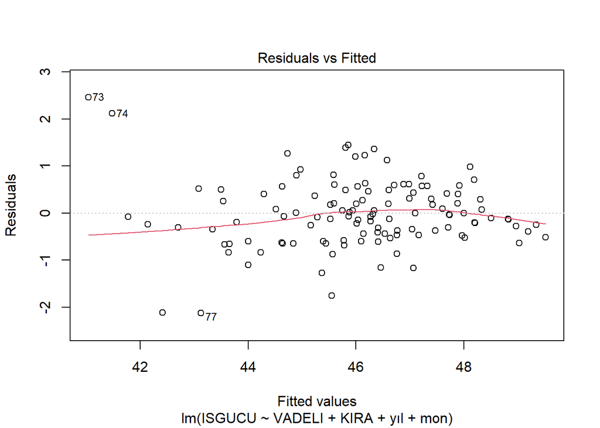

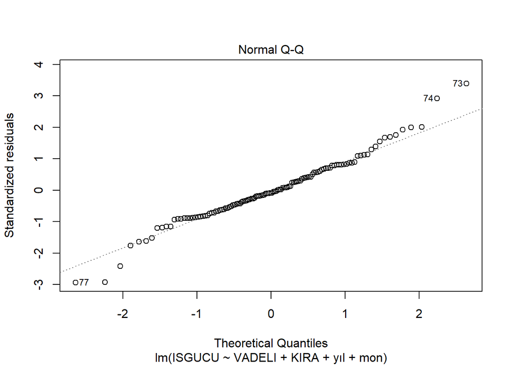

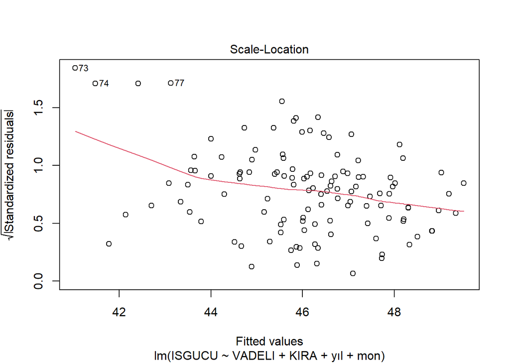

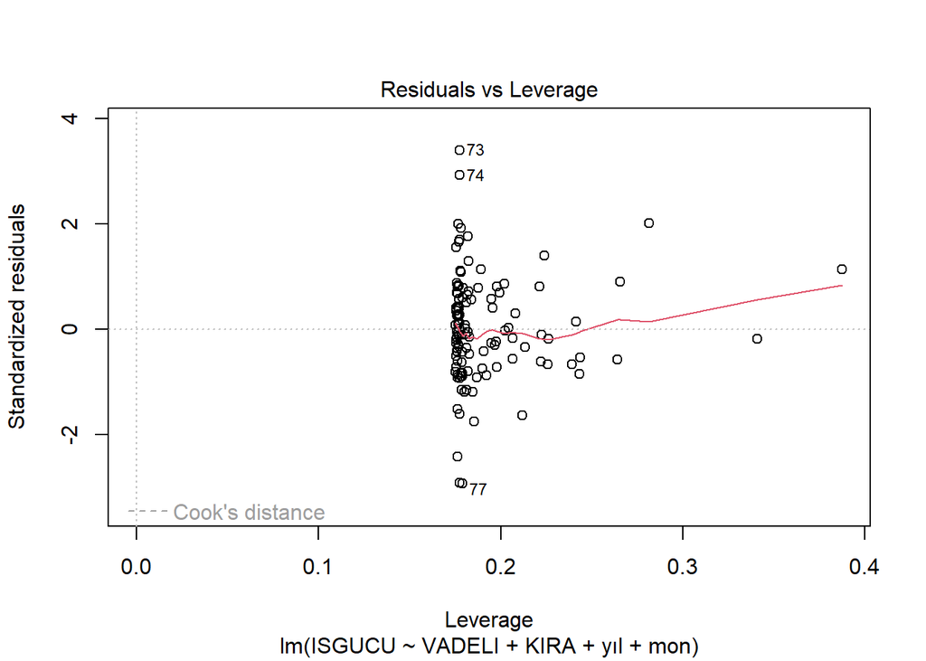

```r
plot(l_fit)
```

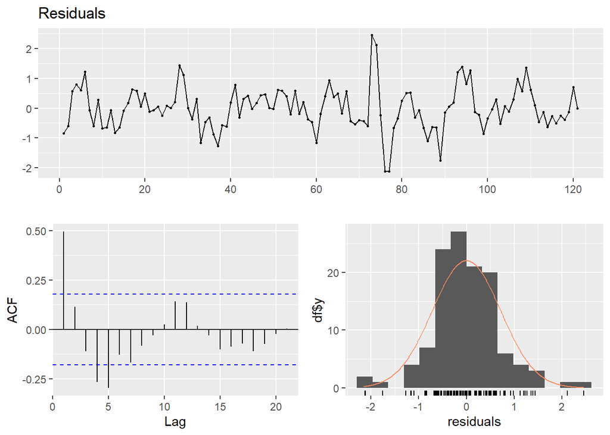

```
##
##  Breusch-Godfrey test for serial correlation of order up to 12
##
## data:  Residuals
## LM test = 53.674, df = 12, p-value = 3.124e-07
```

```r
checkresiduals(l_fit,12)
```

- The R-squared value increased significantly and the residuals are looking better than the first trial. Residuals are also very close to the assumption of Normally distributed.

# 2)Second Model

- In the second model, accommodation costs are in the spotlight. Question is that whether or not accommodation costs can be modeled using rent-a-car level, suitability of the current period to save money and number of buildings that are higher than 2 floors.

```r
konaklama=read_excel("C://Users/erces/Documents/EVDS_5_.xlsx")
konaklama=data.table(konaklama)
konaklama$Tarih <- ym(konaklama$Tarih)
head(konaklama,25)
```

```
##          Tarih KONAKLAMA ARABAKIRA TASARRUF BINASAY
##  1: 2014-03-01    444593     51358 69.36920  139055
##  2: 2014-04-01    481389     53961 74.94002   64802
##  3: 2014-05-01    687447     80331 70.03705  118836
##  4: 2014-06-01    625660     73968 70.36786   79532
##  5: 2014-07-01    595041     74499 72.92307   59005
##  6: 2014-08-01   1022513     92210 71.23493   76525
##  7: 2014-09-01    675022     70097 71.19475   81483
##  8: 2014-10-01    676785     80996 71.78600   44197
##  9: 2014-11-01    449496     66788 73.17738   57874
## 10: 2014-12-01    422996     67057 68.85866   84206
## 11: 2015-01-01    536742     80387 68.94410   46659
## 12: 2015-02-01    530069     69406 64.41953   51205
## 13: 2015-03-01    548668     71386 62.07012   65461
## 14: 2015-04-01    549340     73787 62.11526   70504
## 15: 2015-05-01    810976    107019 60.93016   75450
## 16: 2015-06-01    675256     93140 60.95038   76662
## 17: 2015-07-01   1046009    135012 62.29317   65977
## 18: 2015-08-01   1079098    114797 62.68043   63879
## 19: 2015-09-01    818248    106094 55.28574   54705
## 20: 2015-10-01    799878    114704 54.37325   57405
## 21: 2015-11-01    514514     86078 62.43076   68800
## 22: 2015-12-01    498067     88174 63.27888  107739
## 23: 2016-01-01    624514    101822 63.47336   70929
## 24: 2016-02-01    545368     82471 60.35267   74450
## 25: 2016-03-01    537989     86780 58.04038   83228
##          Tarih KONAKLAMA ARABAKIRA TASARRUF BINASAY
```

- Examining the graph of the accommodation costs, there are seasonality and trend. We can also say that variance of the data is increasing which indicates use of logarithms.

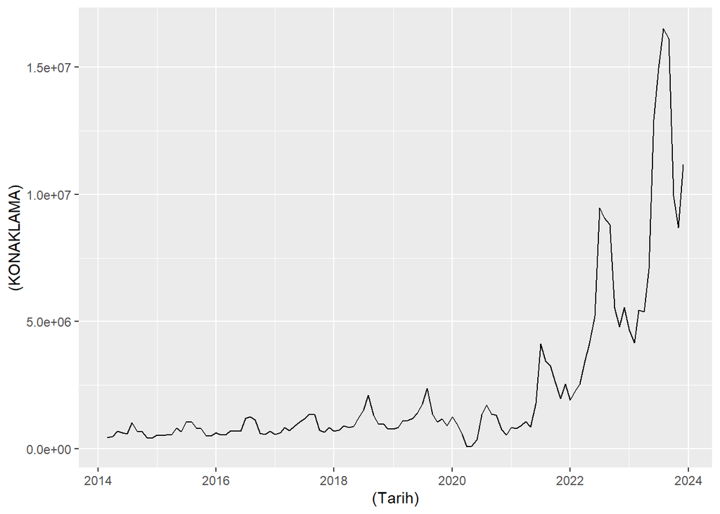

```r
ggplot(konaklama ,aes(x=(Tarih),y=(KONAKLAMA))) + geom_line()
```

- In the correlation table it is understood that number of buildings is not going to help us in the model.

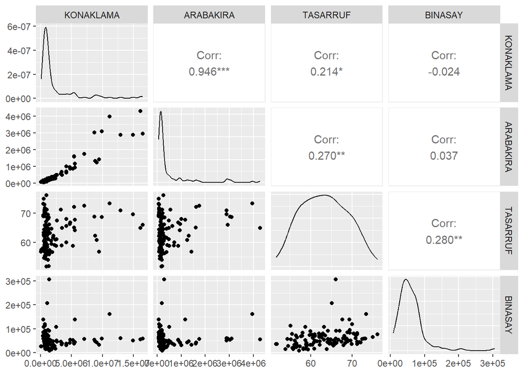

```r
konaklama_correlation <- read_excel("C://Users/erces/Documents/konaklama_correlation.xlsx")
ggpairs(konaklama_correlation)
```

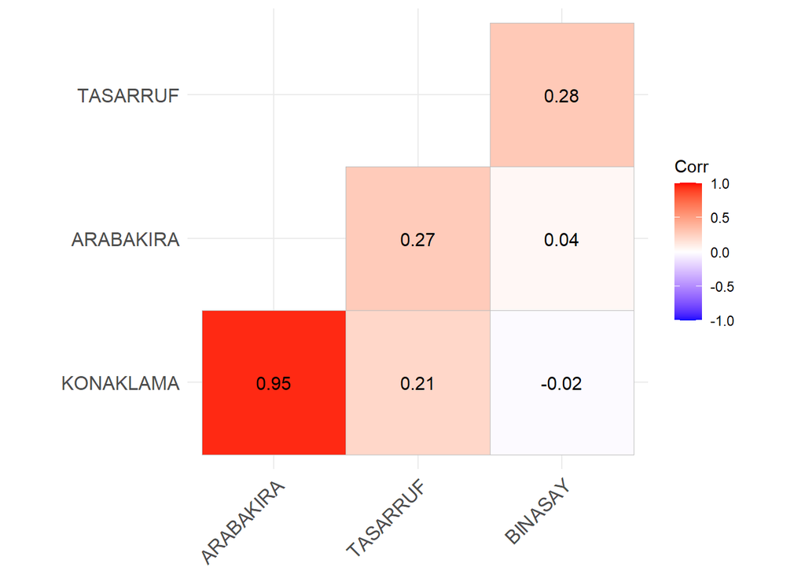

```r
correl_info=cor(konaklama_correlation)

ggcorrplot(correl_info,
           hc.order = TRUE,
           type = "lower",
           lab = TRUE)
```

```r
konaklama$KONAKLAMA <- log(konaklama$KONAKLAMA)
konaklama[,trnd:=1:.N]
konaklama[,mon:=as.character(month(Tarih,label=T))]
konaklama[,yıl:=as.character(year(Tarih))]

l_fit = lm(KONAKLAMA~ARABAKIRA+TASARRUF+mon+yıl,data=konaklama)
l_fit
```

```
##
## Call:
## lm(formula = KONAKLAMA ~ ARABAKIRA + TASARRUF + mon + yıl, data = konaklama)
##
## Coefficients:
## (Intercept)    ARABAKIRA     TASARRUF       monAra       monEki       monEyl
##   1.347e+01    3.254e-07    4.832e-03   -7.096e-01   -5.036e-01   -2.563e-01
##      monHaz       monKas       monMar       monMay       monNis       monOca
##  -5.550e-01   -6.948e-01   -8.245e-01   -8.216e-01   -9.893e-01   -8.730e-01
##      monŞub       monTem      yıl2015      yıl2016      yıl2017      yıl2018
##  -8.848e-01   -1.559e-01    2.329e-01    3.060e-01    4.516e-01    6.218e-01
##     yıl2019      yıl2020      yıl2021      yıl2022      yıl2023
##   7.896e-01    1.278e-01    1.041e+00    1.904e+00    1.979e+00
```

```r
summary(l_fit)
```

```
##
## Call:
## lm(formula = KONAKLAMA ~ ARABAKIRA + TASARRUF + mon + yıl, data = konaklama)
##
## Residuals:
##      Min       1Q   Median       3Q      Max
## -1.69234 -0.13836  0.02545  0.16004  0.98908
##
## Coefficients:
##               Estimate Std. Error t value Pr(>|t|)
## (Intercept)  1.347e+01  6.313e-01  21.331  < 2e-16 ***
## ARABAKIRA    3.254e-07  1.037e-07   3.138 0.002265 **
## TASARRUF     4.832e-03  8.485e-03   0.569 0.570404
## monAra      -7.096e-01  1.586e-01  -4.474 2.13e-05 ***
## monEki      -5.036e-01  1.579e-01  -3.189 0.001932 **
## monEyl      -2.563e-01  1.589e-01  -1.613 0.110006
## monHaz      -5.550e-01  1.584e-01  -3.503 0.000703 ***
## monKas      -6.948e-01  1.582e-01  -4.391 2.93e-05 ***
## monMar      -8.245e-01  1.608e-01  -5.127 1.55e-06 ***
## monMay      -8.216e-01  1.602e-01  -5.129 1.54e-06 ***
## monNis      -9.893e-01  1.603e-01  -6.170 1.67e-08 ***
## monOca      -8.730e-01  1.677e-01  -5.205 1.12e-06 ***
## monŞub      -8.848e-01  1.679e-01  -5.269 8.55e-07 ***
## monTem      -1.559e-01  1.579e-01  -0.987 0.326183
## yıl2015      2.329e-01  1.732e-01   1.345 0.181870
## yıl2016      3.060e-01  1.692e-01   1.808 0.073809 .
## yıl2017      4.516e-01  1.686e-01   2.679 0.008713 **
## yıl2018      6.218e-01  1.785e-01   3.482 0.000753 ***
## yıl2019      7.896e-01  1.897e-01   4.161 6.94e-05 ***
## yıl2020      1.278e-01  1.801e-01   0.709 0.479876
## yıl2021      1.041e+00  1.610e-01   6.464 4.36e-09 ***
## yıl2022      1.904e+00  1.987e-01   9.584 1.28e-15 ***
## yıl2023      1.979e+00  3.006e-01   6.582 2.53e-09 ***
## ---
## Signif. codes:  0 '***' 0.001 '**' 0.01 '*' 0.05 '.' 0.1 ' ' 1
##
## Residual standard error: 0.3529 on 95 degrees of freedom
## Multiple R-squared:  0.8979, Adjusted R-squared:  0.8743
## F-statistic: 37.99 on 22 and 95 DF,  p-value: < 2.2e-16
```

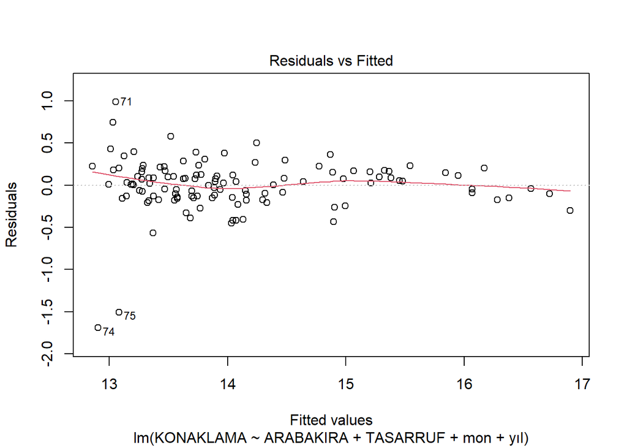

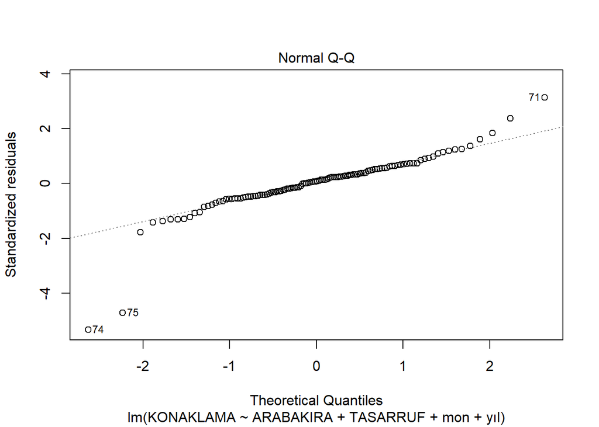

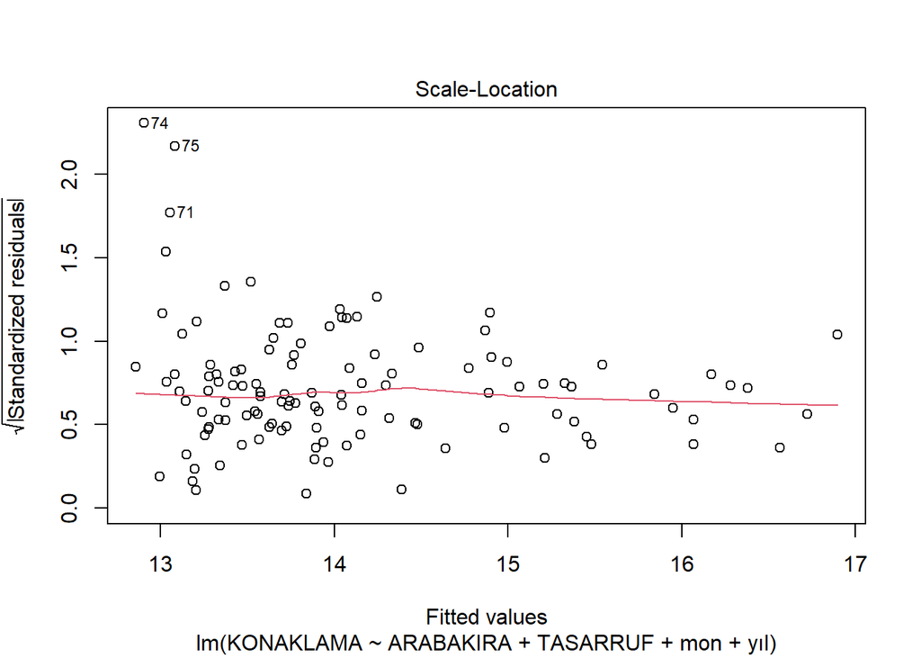

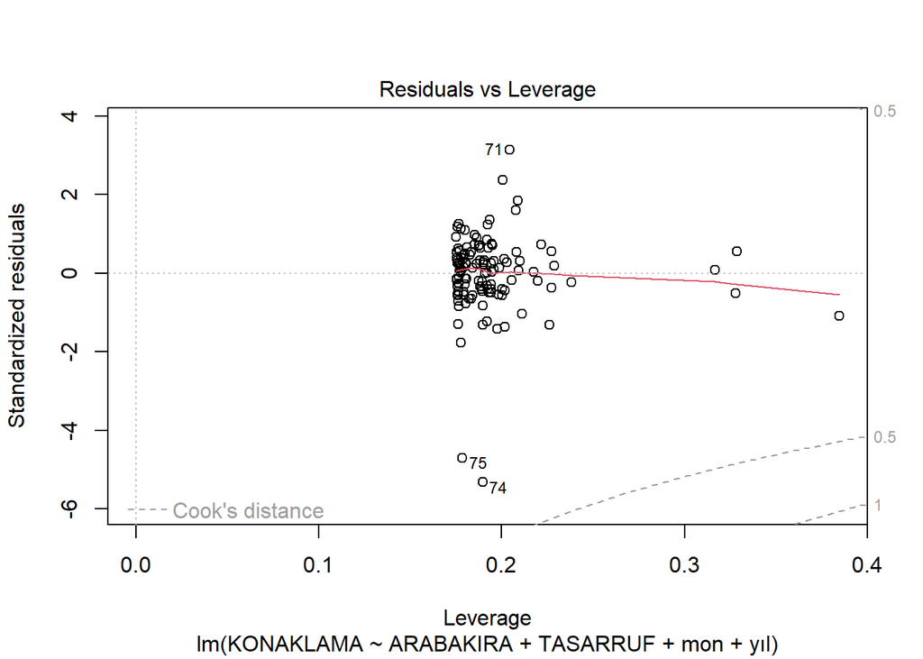

```r
plot(l_fit)
```

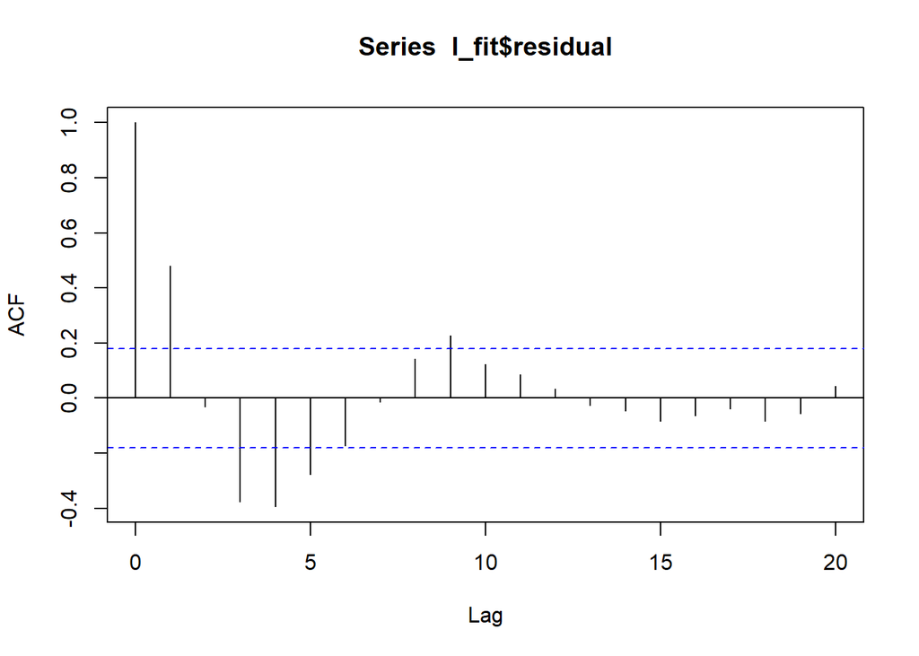

```r
acf(l_fit$residual)
```

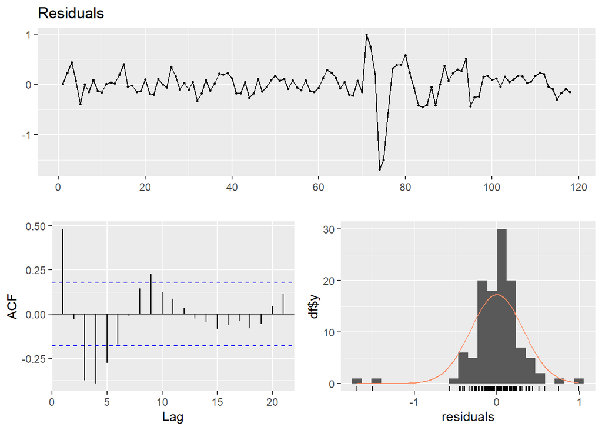

```
##
##  Breusch-Godfrey test for serial correlation of order up to 12
##
## data:  Residuals
## LM test = 59.282, df = 12, p-value = 3.051e-08
```

```r
checkresiduals(l_fit,12)
```

- Residuals seem reasonable but there is a out-liner in the COVID area that may effect our results.

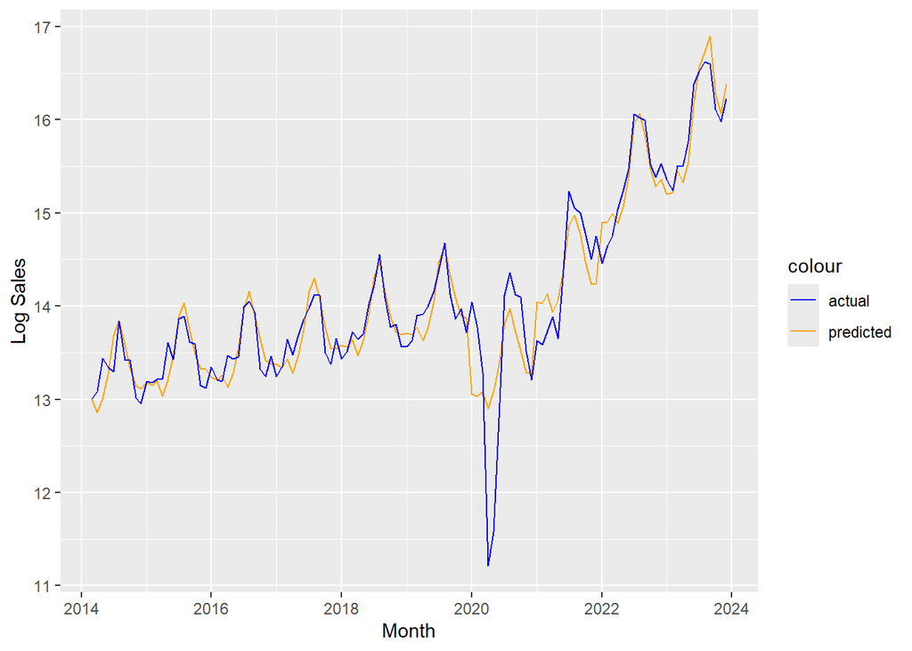

```r
konaklama$fitted <- fitted(l_fit)
konaklama$residual <- residuals(l_fit)
cols <- c("predicted" = "orange","actual" = "blue")
ggplot() +
  geom_line(data = konaklama, aes(x = Tarih,y = fitted, color = "predicted")) +
  geom_line(data = konaklama, aes(x = Tarih,y = KONAKLAMA, color = "actual")) +
  xlab("Month") +
  ylab("Log Sales") +
  scale_color_manual(values = cols)
```

- Our model is looking similar to the actual data however, it is mistaken in the COVID period which may effect our overall result.

# 3)Third Model

- In the third model it is examined if the manufacturing industry capacity utilization rate can be modeled by the data of Euro-TL exchange rate, food price index, and exported food value index.

```r
gıda=read_excel("C://Users/erces/Documents/EVDS (6).xlsx")
gıda=data.table(gıda)
gıda$Tarih <- ym(gıda$Tarih)
head(gıda,25)
```

```
##          Tarih   EUR_TL GIDAFIYAT ITHALGIDA IMALAT
##  1: 2013-01-01 2.352659    231.40  117.7572   72.0
##  2: 2013-02-01 2.377090    233.57  116.8142   72.0
##  3: 2013-03-01 2.349043    238.59  113.6779   70.8
##  4: 2013-04-01 2.339733    235.25  113.5992   71.5
##  5: 2013-05-01 2.370900    229.64  117.0856   71.2
##  6: 2013-06-01 2.503145    234.09  119.4995   71.5
##  7: 2013-07-01 2.528509    234.64  120.8187   73.1
##  8: 2013-08-01 2.606516    232.65  112.8787   72.6
##  9: 2013-09-01 2.695024    234.37  117.8871   72.6
## 10: 2013-10-01 2.718067    244.15  115.9589   75.2
## 11: 2013-11-01 2.734014    240.52  115.5595   74.5
## 12: 2013-12-01 2.823091    244.14  120.5131   75.3
## 13: 2014-01-01 3.026973    257.57  112.5085   72.5
## 14: 2014-02-01 3.024850    257.79  114.1167   72.1
## 15: 2014-03-01 3.071300    263.46  113.3823   71.6
## 16: 2014-04-01 2.943548    267.36  116.2084   71.0
## 17: 2014-05-01 2.879650    263.40  125.0530   70.6
## 18: 2014-06-01 2.880929    264.17  116.9164   71.5
## 19: 2014-07-01 2.881610    264.79  119.3764   71.7
## 20: 2014-08-01 2.882033    267.08  118.7863   69.9
## 21: 2014-09-01 2.855273    267.82  115.9468   71.5
## 22: 2014-10-01 2.869330    275.22  111.7330   74.0
## 23: 2014-11-01 2.792205    275.79  111.3512   73.7
## 24: 2014-12-01 2.826787    275.74  118.2713   73.7
## 25: 2015-01-01 2.721110    286.11  106.6081   73.9
##          Tarih   EUR_TL GIDAFIYAT ITHALGIDA IMALAT
```

- There may be some seasonality with the data and a slight trend.

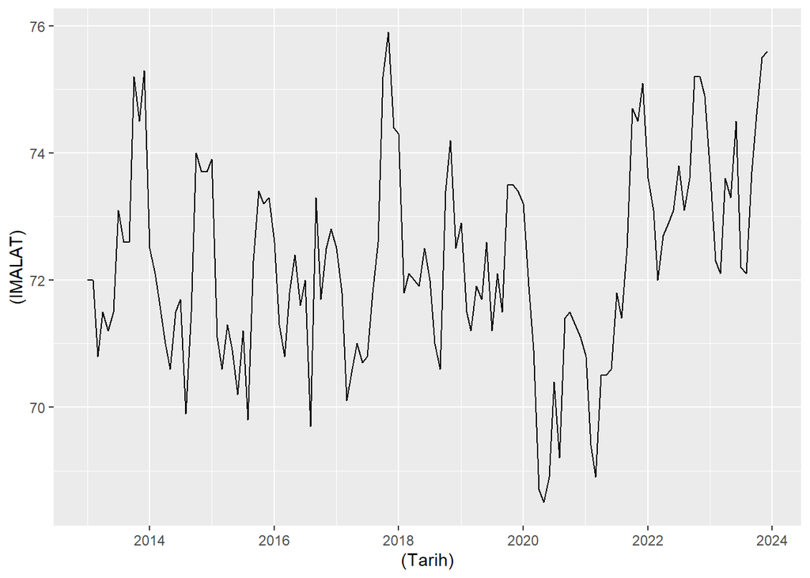

```r
ggplot(gıda ,aes(x=(Tarih),y=(IMALAT))) + geom_line()
```

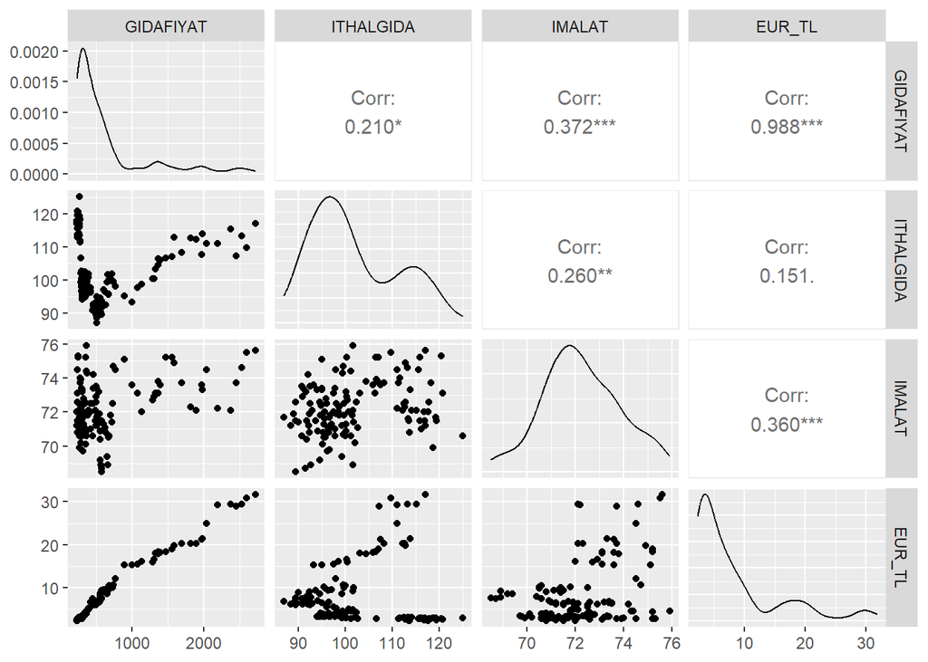

```r
gıda_corelation <- read_excel("C://Users/erces/Documents/gıda_corelation.xlsx")
ggpairs(gıda_corelation)
```

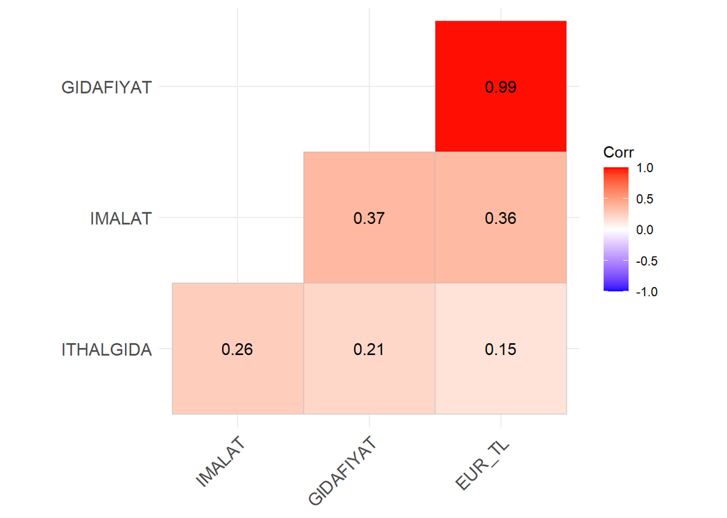

```r
correl_info=cor(gıda_corelation)

ggcorrplot(correl_info,
           hc.order = TRUE,
           type = "lower",
           lab = TRUE)
```

- Doing similar model with previous one.

```r
gıda[,trnd:=1:.N]
gıda[,mon:=as.character(month(Tarih,label=T))]
gıda[,yıl:=as.character(year(Tarih))]
l_fit = lm(IMALAT~GIDAFIYAT+ITHALGIDA+EUR_TL+yıl+mon,data=gıda)
l_fit
```

```
##
## Call:
## lm(formula = IMALAT ~ GIDAFIYAT + ITHALGIDA + EUR_TL + yıl +
##     mon, data = gıda)
##
## Coefficients:
## (Intercept)    GIDAFIYAT    ITHALGIDA       EUR_TL      yıl2014      yıl2015
##   68.338244     0.001024     0.027017    -0.059419    -0.698277    -0.502860
##     yıl2016      yıl2017      yıl2018      yıl2019      yıl2020      yıl2021
##   -0.280980     0.064295     0.217814     0.219240    -1.477230    -0.479236
##     yıl2022      yıl2023       monAra       monEki       monEyl       monHaz
##    1.054638     0.429051     2.622965     2.704827     1.201549     0.467810
##      monKas       monMar       monMay       monNis       monOca       monŞub
##    2.841334    -0.126041     0.207935     0.283447     1.840231     0.532182
##      monTem
##    0.692673
```

```r
summary(l_fit)
```

```
##
## Call:
## lm(formula = IMALAT ~ GIDAFIYAT + ITHALGIDA + EUR_TL + yıl +
##     mon, data = gıda)
##
## Residuals:
##      Min       1Q   Median       3Q      Max
## -1.83294 -0.58007  0.00552  0.52107  2.04327
##
## Coefficients:
##              Estimate Std. Error t value Pr(>|t|)
## (Intercept) 68.338244   3.345601  20.426  < 2e-16 ***
## GIDAFIYAT    0.001024   0.001749   0.585  0.55964
## ITHALGIDA    0.027017   0.028538   0.947  0.34593
## EUR_TL      -0.059419   0.128564  -0.462  0.64489
## yıl2014     -0.698277   0.369656  -1.889  0.06160 .
## yıl2015     -0.502860   0.622986  -0.807  0.42136
## yıl2016     -0.280980   0.719277  -0.391  0.69684
## yıl2017      0.064295   0.658735   0.098  0.92243
## yıl2018      0.217814   0.706762   0.308  0.75854
## yıl2019      0.219240   0.876414   0.250  0.80295
## yıl2020     -1.477230   0.840900  -1.757  0.08183 .
## yıl2021     -0.479236   0.800283  -0.599  0.55055
## yıl2022      1.054638   1.101716   0.957  0.34059
## yıl2023      0.429051   1.672776   0.256  0.79806
## monAra       2.622965   0.390285   6.721 9.10e-10 ***
## monEki       2.704827   0.388681   6.959 2.86e-10 ***
## monEyl       1.201549   0.387190   3.103  0.00245 **
## monHaz       0.467810   0.386318   1.211  0.22858
## monKas       2.841334   0.388990   7.304 5.22e-11 ***
## monMar      -0.126041   0.401253  -0.314  0.75404
## monMay       0.207935   0.395200   0.526  0.59987
## monNis       0.283447   0.404963   0.700  0.48549
## monOca       1.840231   0.402714   4.570 1.32e-05 ***
## monŞub       0.532182   0.401995   1.324  0.18837
## monTem       0.692673   0.384684   1.801  0.07458 .
## ---
## Signif. codes:  0 '***' 0.001 '**' 0.01 '*' 0.05 '.' 0.1 ' ' 1
##
## Residual standard error: 0.9014 on 107 degrees of freedom
## Multiple R-squared:  0.7347, Adjusted R-squared:  0.6751
## F-statistic: 12.34 on 24 and 107 DF,  p-value: < 2.2e-16
```